# SANJEEV_MT_Project_LearnerNotebook_FullCode__

## Problem Statement

### Business Context

Renewable energy sources play an increasingly important role in the global energy mix, as the effort to reduce the environmental impact of energy production increases.

Out of all the renewable energy alternatives, wind energy is one of the most developed technologies worldwide. The U.S Department of Energy has put together a guide to achieving operational efficiency using predictive maintenance practices.

Predictive maintenance uses sensor information and analysis methods to measure and predict degradation and future component capability. The idea behind predictive maintenance is that failure patterns are predictable and if component failure can be predicted accurately and the component is replaced before it fails, the costs of operation and maintenance will be much lower.

The sensors fitted across different machines involved in the process of energy generation collect data related to various environmental factors (temperature, humidity, wind speed, etc.) and additional features related to various parts of the wind turbine (gearbox, tower, blades, break, etc.).

## Objective

“ReneWind” is a company working on improving the machinery/processes involved in the production of wind energy using machine learning and has collected data of generator failure of wind turbines using sensors. They have shared a ciphered version of the data, as the data collected through sensors is confidential (the type of data collected varies with companies). Data has 40 predictors, 20000 observations in the training set and 5000 in the test set.

The objective is to build various classification models, tune them, and find the best one that will help identify failures so that the generators could be repaired before failing/breaking to reduce the overall maintenance cost. The nature of predictions made by the classification model will translate as follows:

- True positives (TP) are failures correctly predicted by the model. These will result in repairing costs.
- False negatives (FN) are real failures where there is no detection by the model. These will result in replacement costs.
- False positives (FP) are detections where there is no failure. These will result in inspection costs.

It is given that the cost of repairing a generator is much less than the cost of replacing it, and the cost of inspection is less than the cost of repair.

“1” in the target variables should be considered as “failure” and “0” represents “No failure”.

## Data Description

- The data provided is a transformed version of original data which was collected using sensors.
- Train.csv - To be used for training and tuning of models.
- Test.csv - To be used only for testing the performance of the final best model.
- Both the datasets consist of 40 predictor variables and 1 target variable

## Importing necessary libraries

```python
# # Installing the libraries with the specified version.
# !pip install pandas==1.5.3 numpy==1.25.2 matplotlib==3.7.1 seaborn==0.13.1 scikit-learn==1.2.2 imbalanced-learn==0.10.1 xgboost==2.0.3 threadpoolctl==3.3.0 -q --user
```

**Note:** After running the above cell, kindly restart the notebook kernel and run all cells sequentially from the start again.

```python
 # importing library for data manupulation
import numpy as np
import pandas as pd
import matplotlib.pyplot as plt
import seaborn as sns

 # for spliting data into train and validation
from sklearn.model_selection import train_test_split
 # for cross validation
from sklearn.model_selection import StratifiedKFold
 # for cross validation score
from sklearn.model_selection import cross_val_score
 # for checking performance
from sklearn import metrics
from sklearn.metrics import (
    f1_score,
    confusion_matrix,
    accuracy_score,
    precision_score,
    recall_score,
    roc_auc_score,
    ConfusionMatrixDisplay,
 )

# for Building model and boosting
from sklearn.linear_model import LogisticRegression
from sklearn.tree import DecisionTreeClassifier
from sklearn.ensemble import (
    BaggingClassifier,
    RandomForestClassifier,
    AdaBoostClassifier,
    GradientBoostingClassifier,
    StackingClassifier,
)
from xgboost import XGBClassifier

 # for data scaling and one hot encoding
from sklearn.preprocessing import StandardScaler, MinMaxScaler, OneHotEncoder
# for imputing missing values
from sklearn.impute import SimpleImputer

# for oversample and undersample data
from imblearn.over_sampling import SMOTE
from imblearn.under_sampling import RandomUnderSampler
# for hyperparameter tuning
from sklearn.model_selection import RandomizedSearchCV
# for creating pipelines
from sklearn.pipeline import Pipeline
from sklearn.compose import ColumnTransformer
# for tune different models
from sklearn.model_selection import GridSearchCV


# for statics
import statsmodels.stats.api as sms
import statsmodels.api as sm

# for displaying maximum columns and rows
pd.set_option("display.max_columns", None)
pd.set_option("display.max_rows", None)
pd.set_option("display.float_format", lambda x: "%.3f" % x)

 # for filter warnings
import warnings
warnings.filterwarnings("ignore")
```

## Loading the dataset

```python
#uploading csv file into google colab
from google.colab import files
import io
try:
  uploaded
except:
  uploaded=files.upload()
```

Upload widget is only available when the cell has been executed in the current browser session. Please rerun this cell to enable.

```
Saving Train (3).csv to Train (3).csv
```

```python
#importing test set
from google.colab import files
import io
try:
  uploaded_
except:
  uploaded_1=files.upload()
```

Upload widget is only available when the cell has been executed in the current browser session. Please rerun this cell to enable.

```
Saving Test (1).csv to Test (1).csv
```

```python
# reading the csv files
train=pd.read_csv("Train (3).csv")
test_1=pd.read_csv("Test (1).csv")
```

```python
# copying data to keep safe
df=train.copy()
dff=test_1.copy()
```

## Data Overview

- Observations
- Sanity checks

```python
#checking top 5 rows
df.head(5).style.set_properties(**{'background-color': 'yellow', 'color': 'darkblue','border-color': 'blue','border-width': '8px','border-style': 'solid',})
```

|  | V1 | V2 | V3 | V4 | V5 | V6 | V7 | V8 | V9 | V10 | V11 | V12 | V13 | V14 | V15 | V16 | V17 | V18 | V19 | V20 | V21 | V22 | V23 | V24 | V25 | V26 | V27 | V28 | V29 | … |
| --- | --- | --- | --- | --- | --- | --- | --- | --- | --- | --- | --- | --- | --- | --- | --- | --- | --- | --- | --- | --- | --- | --- | --- | --- | --- | --- | --- | --- | --- | --- |
| 0 | -4.464606 | -4.679129 | 3.101546 | 0.506130 | -0.221083 | -2.032511 | -2.910870 | 0.050714 | -1.522351 | 3.761892 | -5.714719 | 0.735893 | 0.981251 | 1.417884 | -3.375815 | -3.047303 | 0.306194 | 2.914097 | 2.269979 | 4.394876 | -2.388299 | 0.646388 | -1.190508 | 3.132986 | 0.665277 | -2.510846 | -0.036744 | 0.726218 | -3.982187 | … |
| 1 | 3.365912 | 3.653381 | 0.909671 | -1.367528 | 0.332016 | 2.358938 | 0.732600 | -4.332135 | 0.565695 | -0.101080 | 1.914465 | -0.951458 | -1.255259 | -2.706522 | 0.193223 | -4.769379 | -2.205319 | 0.907716 | 0.756894 | -5.833678 | -3.065122 | 1.596647 | -1.757311 | 1.766444 | -0.267098 | 3.625036 | 1.500346 | -0.585712 | 0.783034 | … |
| 2 | -3.831843 | -5.824444 | 0.634031 | -2.418815 | -1.773827 | 1.016824 | -2.098941 | -3.173204 | -2.081860 | 5.392621 | -0.770673 | 1.106718 | 1.144261 | 0.943301 | -3.163804 | -4.247825 | -4.038909 | 3.688534 | 3.311196 | 1.059002 | -2.143026 | 1.650120 | -1.660592 | 1.679910 | -0.450782 | -4.550695 | 3.738779 | 1.134404 | -2.033531 | … |
| 3 | 1.618098 | 1.888342 | 7.046143 | -1.147285 | 0.083080 | -1.529780 | 0.207309 | -2.493629 | 0.344926 | 2.118578 | -3.053023 | 0.459719 | 2.704527 | -0.636086 | -0.453717 | -3.174046 | -3.404347 | -1.281536 | 1.582104 | -1.951778 | -3.516555 | -1.206011 | -5.627854 | -1.817653 | 2.124142 | 5.294642 | 4.748137 | -2.308536 | -3.962977 | … |
| 4 | -0.111440 | 3.872488 | -3.758361 | -2.982897 | 3.792714 | 0.544960 | 0.205433 | 4.848994 | -1.854920 | -6.220023 | 1.998347 | 4.723757 | 0.709113 | -1.989432 | -2.632684 | 4.184447 | 2.245356 | 3.734452 | -6.312766 | -5.379918 | -0.886667 | 2.061694 | 9.445586 | 4.489976 | -3.945144 | 4.582065 | -8.780422 | -3.382967 | 5.106507 | … |

```python
# checking bottom 5 rows
df.tail(5).style.set_properties(**{'background-color': 'yellow', 'color': 'darkblue','border-color': 'blue','border-width': '8px','border-style': 'solid',})
```

|  | V1 | V2 | V3 | V4 | V5 | V6 | V7 | V8 | V9 | V10 | V11 | V12 | V13 | V14 | V15 | V16 | V17 | V18 | V19 | V20 | V21 | V22 | V23 | V24 | V25 | V26 | V27 | V28 | V29 | … |
| --- | --- | --- | --- | --- | --- | --- | --- | --- | --- | --- | --- | --- | --- | --- | --- | --- | --- | --- | --- | --- | --- | --- | --- | --- | --- | --- | --- | --- | --- | --- |
| 19995 | -2.071318 | -1.088279 | -0.796174 | -3.011720 | -2.287540 | 2.807310 | 0.481428 | 0.105171 | -0.586599 | -2.899398 | 8.868415 | 1.717155 | 1.357838 | -1.777135 | 0.709780 | 4.944939 | -3.100454 | -1.199228 | -1.084629 | -0.365044 | 3.131175 | -3.948103 | -3.578469 | -8.139067 | -1.936861 | -1.327691 | -0.402688 | -1.734796 | 9.996461 | … |
| 19996 | 2.890264 | 2.483069 | 5.643919 | 0.937053 | -1.380870 | 0.412051 | -1.593386 | -5.762498 | 2.150096 | 0.272302 | -2.094760 | -1.525834 | 0.071573 | -3.540142 | -2.762006 | -10.632206 | -0.495236 | 1.720074 | 3.871596 | -1.209610 | -8.222073 | 2.120866 | -5.491808 | 1.452340 | 1.450002 | 3.684654 | 1.076760 | -0.384175 | -0.838593 | … |
| 19997 | -3.896979 | -3.942407 | -0.351364 | -2.417462 | 1.107546 | -1.527623 | -3.519882 | 2.054792 | -0.233996 | -0.357687 | -3.781972 | 2.180042 | 6.111780 | 1.984747 | -8.330002 | -1.639184 | -0.914960 | 5.672348 | -3.924200 | 2.133196 | -4.502031 | 2.777178 | 5.727949 | 1.619818 | -1.699691 | -0.041882 | -2.923094 | -2.760158 | -2.253766 | … |
| 19998 | -3.187322 | -10.051662 | 5.695955 | -4.370053 | -5.354758 | -1.873044 | -3.947210 | 0.679420 | -2.389254 | 5.456756 | 1.583029 | 3.571478 | 9.226573 | 2.553587 | -7.039109 | -0.993573 | -9.664938 | 1.155224 | 3.876895 | 3.523634 | -7.015329 | -0.132037 | -3.446179 | -4.801443 | -0.875727 | -3.811854 | 5.422077 | -3.732322 | 0.608811 | … |
| 19999 | -2.686903 | 1.961187 | 6.137088 | 2.600133 | 2.657241 | -4.290882 | -2.344267 | 0.974004 | -1.027462 | 0.497421 | -9.589075 | 3.176560 | 1.054517 | -1.415882 | -4.668611 | -5.405377 | 3.719759 | 2.892923 | 2.328591 | 1.457704 | -6.428543 | 1.818232 | 0.805897 | 7.786026 | 0.330857 | 5.257424 | -4.867417 | -0.818941 | -5.667393 | … |

```python
# checking test data
dff.head(5).style.set_properties(**{'background-color': 'black', 'color': 'white','border-color': 'blue','border-width': '8px','border-style': 'solid',})
```

|  | V1 | V2 | V3 | V4 | V5 | V6 | V7 | V8 | V9 | V10 | V11 | V12 | V13 | V14 | V15 | V16 | V17 | V18 | V19 | V20 | V21 | V22 | V23 | V24 | V25 | V26 | V27 | V28 | V29 | … |
| --- | --- | --- | --- | --- | --- | --- | --- | --- | --- | --- | --- | --- | --- | --- | --- | --- | --- | --- | --- | --- | --- | --- | --- | --- | --- | --- | --- | --- | --- | --- |
| 0 | -0.613489 | -3.819640 | 2.202302 | 1.300420 | -1.184929 | -4.495964 | -1.835817 | 4.722989 | 1.206140 | -0.341909 | -5.122874 | 1.017021 | 4.818549 | 3.269001 | -2.984330 | 1.387370 | 2.032002 | -0.511587 | -1.023069 | 7.338733 | -2.242244 | 0.155489 | 2.053786 | -2.772273 | 1.851369 | -1.788696 | -0.277282 | -1.255143 | -3.832886 | … |
| 1 | 0.389608 | -0.512341 | 0.527053 | -2.576776 | -1.016766 | 2.235112 | -0.441301 | -4.405744 | -0.332869 | 1.966794 | 1.796544 | 0.410490 | 0.638328 | -1.389600 | -1.883410 | -5.017922 | -3.827238 | 2.418060 | 1.762285 | -3.242297 | -3.192960 | 1.857454 | -1.707954 | 0.633444 | -0.587898 | 0.083683 | 3.013935 | -0.182309 | 0.223917 | … |
| 2 | -0.874861 | -0.640632 | 4.084202 | -1.590454 | 0.525855 | -1.957592 | -0.695367 | 1.347309 | -1.732348 | 0.466500 | -4.928214 | 3.565070 | -0.449329 | -0.656246 | -0.166537 | -1.630207 | 2.291865 | 2.396492 | 0.601278 | 1.793534 | -2.120238 | 0.481968 | -0.840707 | 1.790197 | 1.874395 | 0.363930 | -0.169063 | -0.483832 | -2.118982 | … |
| 3 | 0.238384 | 1.458607 | 4.014528 | 2.534478 | 1.196987 | -3.117330 | -0.924035 | 0.269493 | 1.322436 | 0.702345 | -5.578345 | -0.850662 | 2.590525 | 0.767418 | -2.390809 | -2.341961 | 0.571875 | -0.933751 | 0.508677 | 1.210715 | -3.259524 | 0.104587 | -0.658875 | 1.498107 | 1.100305 | 4.142988 | -0.248446 | -1.136516 | -5.355810 | … |
| 4 | 5.828225 | 2.768260 | -1.234530 | 2.809264 | -1.641648 | -1.406698 | 0.568643 | 0.965043 | 1.918379 | -2.774855 | -0.530016 | 1.374544 | -0.650941 | -1.679466 | -0.379220 | -4.443143 | 3.893857 | -0.607640 | 2.944931 | 0.367233 | -5.789081 | 4.597528 | 4.450264 | 3.224941 | 0.396701 | 0.247765 | -2.362047 | 1.079378 | -0.473076 | … |

**Target feature is also present in test set.**

```python
# checking shape of the train set
df.shape
```

```
(20000, 41)
```

```python
# checking shape of test set
dff.shape
```

```
(5000, 41)
```

**Observations:**

- there are 20000 rows and 41 columns in train set.
- there are 5000 rows and 41 columns in test set.

```python
# checking datatypes
df.info()
```

```
<class 'pandas.core.frame.DataFrame'>
RangeIndex: 20000 entries, 0 to 19999
Data columns (total 41 columns):
 #   Column  Non-Null Count  Dtype
---  ------  --------------  -----
 0   V1      19982 non-null  float64
 1   V2      19982 non-null  float64
 2   V3      20000 non-null  float64
 3   V4      20000 non-null  float64
 4   V5      20000 non-null  float64
 5   V6      20000 non-null  float64
 6   V7      20000 non-null  float64
 7   V8      20000 non-null  float64
 8   V9      20000 non-null  float64
 9   V10     20000 non-null  float64
```

[output cut: 33 more lines]

**Observations:**

- Dependent feature is inteager.rest are float.
- There is some missing values in V1 an V2.

```python
# checking statical discription
df.describe(include="all").T.style.set_properties(**{'background-color': 'lightblue','color': 'darkblue','border-': 'yellow','border-width': '8px','border-style': 'solid'})
```

|  | count | mean | std | min | 25% | 50% | 75% | max |
| --- | --- | --- | --- | --- | --- | --- | --- | --- |
| V1 | 19982.000000 | -0.271996 | 3.441625 | -11.876451 | -2.737146 | -0.747917 | 1.840112 | 15.493002 |
| V2 | 19982.000000 | 0.440430 | 3.150784 | -12.319951 | -1.640674 | 0.471536 | 2.543967 | 13.089269 |
| V3 | 20000.000000 | 2.484699 | 3.388963 | -10.708139 | 0.206860 | 2.255786 | 4.566165 | 17.090919 |
| V4 | 20000.000000 | -0.083152 | 3.431595 | -15.082052 | -2.347660 | -0.135241 | 2.130615 | 13.236381 |
| V5 | 20000.000000 | -0.053752 | 2.104801 | -8.603361 | -1.535607 | -0.101952 | 1.340480 | 8.133797 |
| V6 | 20000.000000 | -0.995443 | 2.040970 | -10.227147 | -2.347238 | -1.000515 | 0.380330 | 6.975847 |
| V7 | 20000.000000 | -0.879325 | 1.761626 | -7.949681 | -2.030926 | -0.917179 | 0.223695 | 8.006091 |
| V8 | 20000.000000 | -0.548195 | 3.295756 | -15.657561 | -2.642665 | -0.389085 | 1.722965 | 11.679495 |
| V9 | 20000.000000 | -0.016808 | 2.160568 | -8.596313 | -1.494973 | -0.067597 | 1.409203 | 8.137580 |
| V10 | 20000.000000 | -0.012998 | 2.193201 | -9.853957 | -1.411212 | 0.100973 | 1.477045 | 8.108472 |
| V11 | 20000.000000 | -1.895393 | 3.124322 | -14.832058 | -3.922404 | -1.921237 | 0.118906 | 11.826433 |
| V12 | 20000.000000 | 1.604825 | 2.930454 | -12.948007 | -0.396514 | 1.507841 | 3.571454 | 15.080698 |
| V13 | 20000.000000 | 1.580486 | 2.874658 | -13.228247 | -0.223545 | 1.637185 | 3.459886 | 15.419616 |
| V14 | 20000.000000 | -0.950632 | 1.789651 | -7.738593 | -2.170741 | -0.957163 | 0.270677 | 5.670664 |
| V15 | 20000.000000 | -2.414993 | 3.354974 | -16.416606 | -4.415322 | -2.382617 | -0.359052 | 12.246455 |
| V16 | 20000.000000 | -2.925225 | 4.221717 | -20.374158 | -5.634240 | -2.682705 | -0.095046 | 13.583212 |
| V17 | 20000.000000 | -0.134261 | 3.345462 | -14.091184 | -2.215611 | -0.014580 | 2.068751 | 16.756432 |
| V18 | 20000.000000 | 1.189347 | 2.592276 | -11.643994 | -0.403917 | 0.883398 | 2.571770 | 13.179863 |
| V19 | 20000.000000 | 1.181808 | 3.396925 | -13.491784 | -1.050168 | 1.279061 | 3.493299 | 13.237742 |
| V20 | 20000.000000 | 0.023608 | 3.669477 | -13.922659 | -2.432953 | 0.033415 | 2.512372 | 16.052339 |
| V21 | 20000.000000 | -3.611252 | 3.567690 | -17.956231 | -5.930360 | -3.532888 | -1.265884 | 13.840473 |
| V22 | 20000.000000 | 0.951835 | 1.651547 | -10.122095 | -0.118127 | 0.974687 | 2.025594 | 7.409856 |
| V23 | 20000.000000 | -0.366116 | 4.031860 | -14.866128 | -3.098756 | -0.262093 | 2.451750 | 14.458734 |
| V24 | 20000.000000 | 1.134389 | 3.912069 | -16.387147 | -1.468062 | 0.969048 | 3.545975 | 17.163291 |
| V25 | 20000.000000 | -0.002186 | 2.016740 | -8.228266 | -1.365178 | 0.025050 | 1.397112 | 8.223389 |
| V26 | 20000.000000 | 1.873785 | 3.435137 | -11.834271 | -0.337863 | 1.950531 | 4.130037 | 16.836410 |
| V27 | 20000.000000 | -0.612413 | 4.368847 | -14.904939 | -3.652323 | -0.884894 | 2.189177 | 17.560404 |
| V28 | 20000.000000 | -0.883218 | 1.917713 | -9.269489 | -2.171218 | -0.891073 | 0.375884 | 6.527643 |
| V29 | 20000.000000 | -0.985625 | 2.684365 | -12.579469 | -2.787443 | -1.176181 | 0.629773 | 10.722055 |
| V30 | 20000.000000 | -0.015534 | 3.005258 | -14.796047 | -1.867114 | 0.184346 | 2.036229 | 12.505812 |
| V31 | 20000.000000 | 0.486842 | 3.461384 | -13.722760 | -1.817772 | 0.490304 | 2.730688 | 17.255090 |
| V32 | 20000.000000 | 0.303799 | 5.500400 | -19.876502 | -3.420469 | 0.052073 | 3.761722 | 23.633187 |
| V33 | 20000.000000 | 0.049825 | 3.575285 | -16.898353 | -2.242857 | -0.066249 | 2.255134 | 16.692486 |
| V34 | 20000.000000 | -0.462702 | 3.183841 | -17.985094 | -2.136984 | -0.255008 | 1.436935 | 14.358213 |
| V35 | 20000.000000 | 2.229620 | 2.937102 | -15.349803 | 0.336191 | 2.098633 | 4.064358 | 15.291065 |
| V36 | 20000.000000 | 1.514809 | 3.800860 | -14.833178 | -0.943809 | 1.566526 | 3.983939 | 19.329576 |
| V37 | 20000.000000 | 0.011316 | 1.788165 | -5.478350 | -1.255819 | -0.128435 | 1.175533 | 7.467006 |
| V38 | 20000.000000 | -0.344025 | 3.948147 | -17.375002 | -2.987638 | -0.316849 | 2.279399 | 15.289923 |
| V39 | 20000.000000 | 0.890653 | 1.753054 | -6.438880 | -0.272250 | 0.919261 | 2.057540 | 7.759877 |
| V40 | 20000.000000 | -0.875630 | 3.012155 | -11.023935 | -2.940193 | -0.920806 | 1.119897 | 10.654265 |
| Target | 20000.000000 | 0.055500 | 0.228959 | 0.000000 | 0.000000 | 0.000000 | 0.000000 | 1.000000 |

**Observations:**

- Some features have negative means, while others have positive means, indicating different central tendencies across the dataset.
- The target variable ("Target") is binary, with values of 0 and 1.
- Each feature (V1 to V40) has a different distribution and statistical characteristics, such as mean, standard deviation, minimum, maximum, and quartiles.
- Some features have negative means, while others have positive means, indicating different central tendencies across the dataset.

## Exploratory Data Analysis (EDA)

### Plotting histograms and boxplots for all the variables

```python
# function to plot a boxplot and a histogram along the same scale.


def histogram_boxplot(data, feature, figsize=(12, 7), kde=False, bins=None):
    """
    Boxplot and histogram combined

    data: dataframe
    feature: dataframe column
    figsize: size of figure (default (12,7))
    kde: whether to the show density curve (default False)
    bins: number of bins for histogram (default None)
    """
    f2, (ax_box2, ax_hist2) = plt.subplots(
        nrows=2,  # Number of rows of the subplot grid= 2
        sharex=True,  # x-axis will be shared among all subplots
        gridspec_kw={"height_ratios": (0.25, 0.75)},
        figsize=figsize,
    )  # creating the 2 subplots
    sns.boxplot(
        data=data, x=feature, ax=ax_box2, showmeans=True, color="violet"
    )  # boxplot will be created and a star will indicate the mean value of the column
    sns.histplot(
        data=data, x=feature, kde=kde, ax=ax_hist2, bins=bins, palette="winter"
    ) if bins else sns.histplot(
        data=data, x=feature, kde=kde, ax=ax_hist2
    )  # For histogram
    ax_hist2.axvline(
        data[feature].mean(), color="green", linestyle="--"
    )  # Add mean to the histogram
    ax_hist2.axvline(
        data[feature].median(), color="black", linestyle="-"
    )  # Add median to the histogram
```

### Plotting all the features at one go

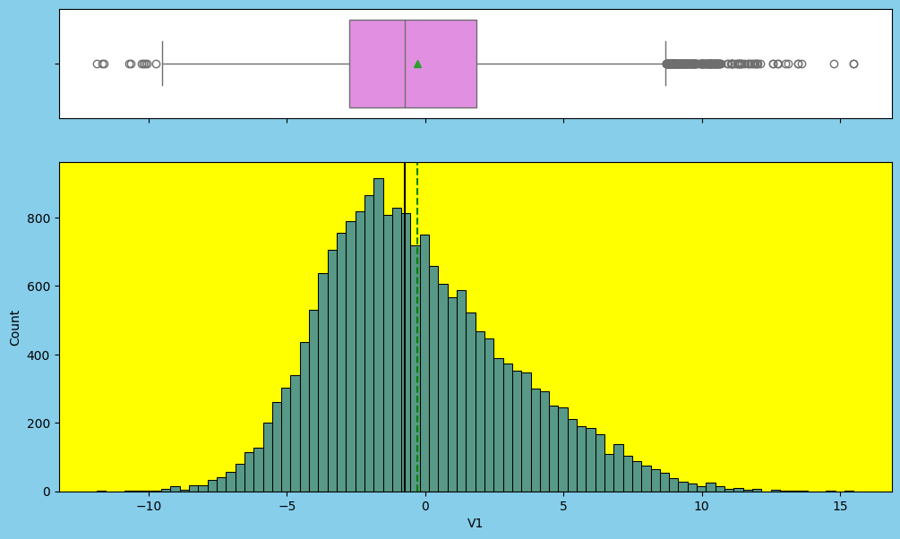

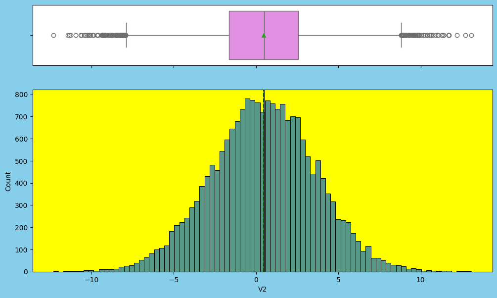

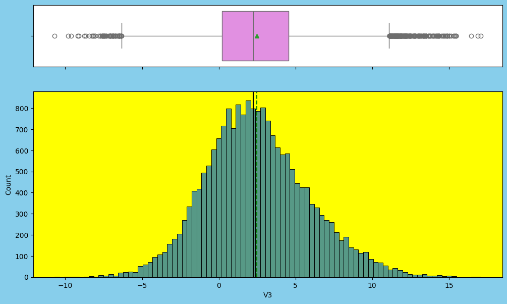

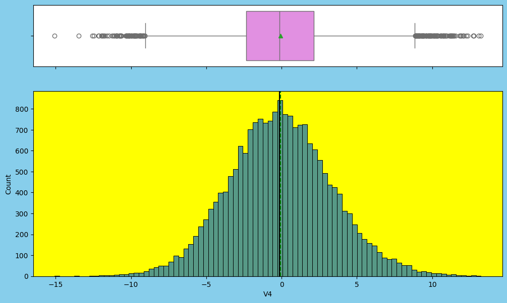

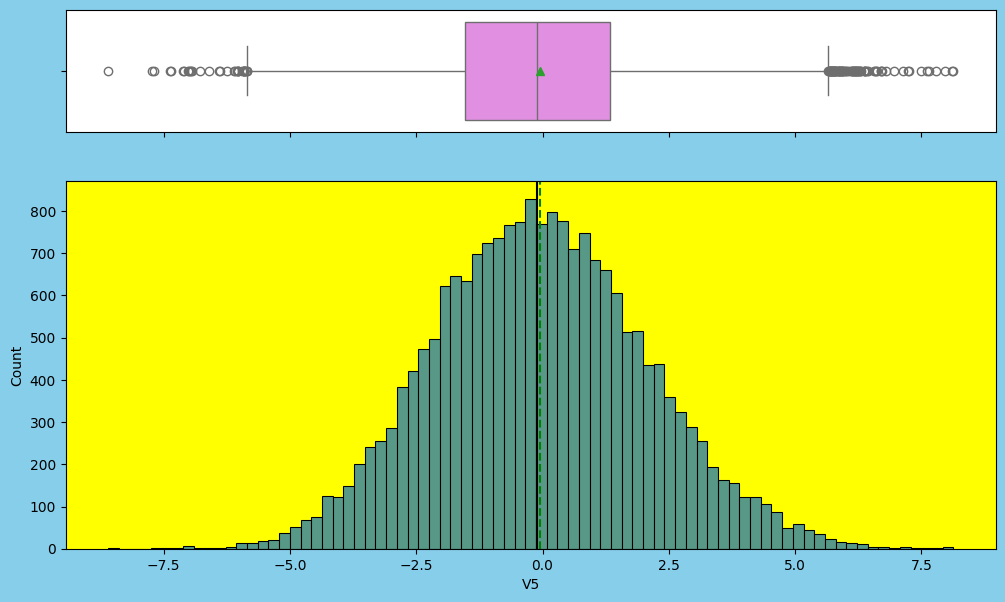

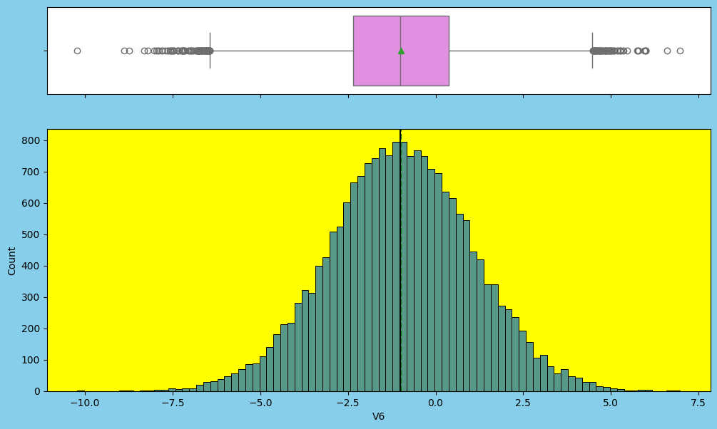

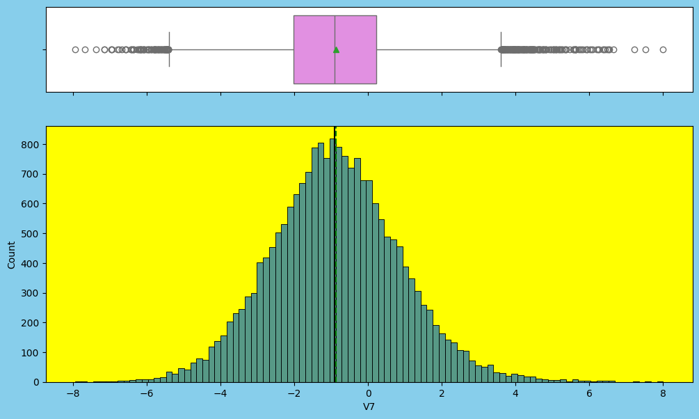

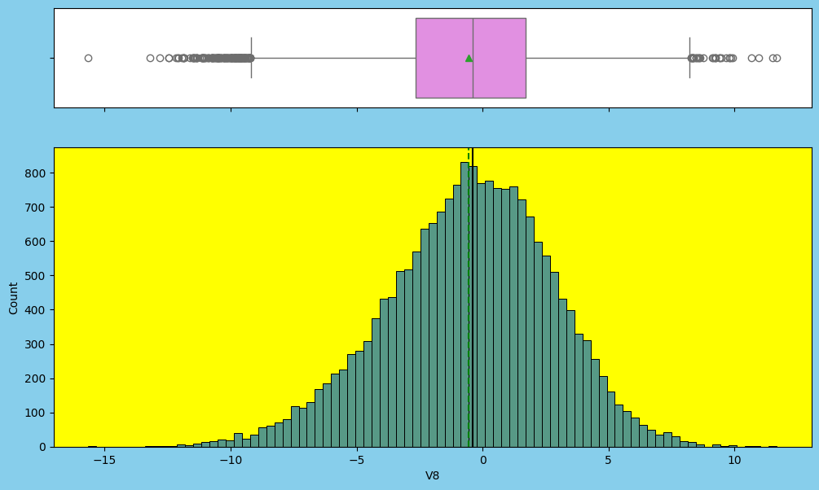

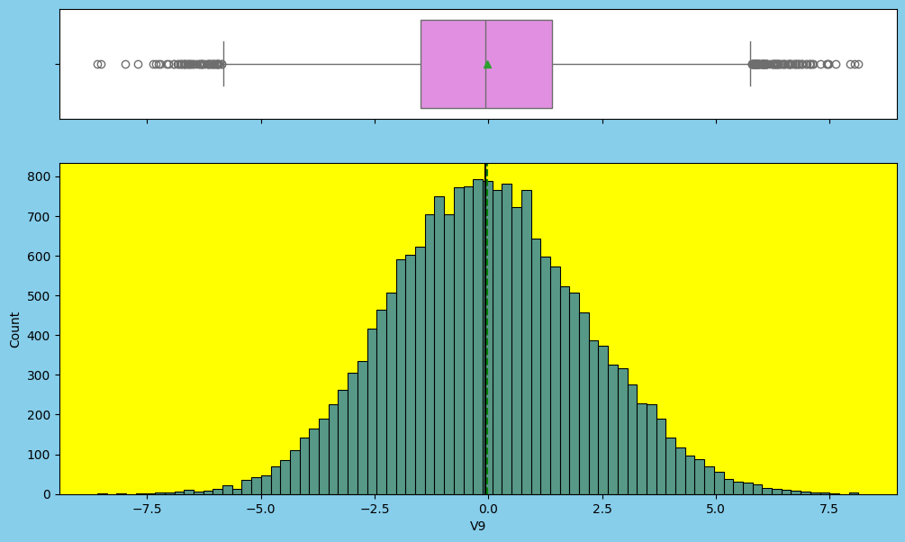

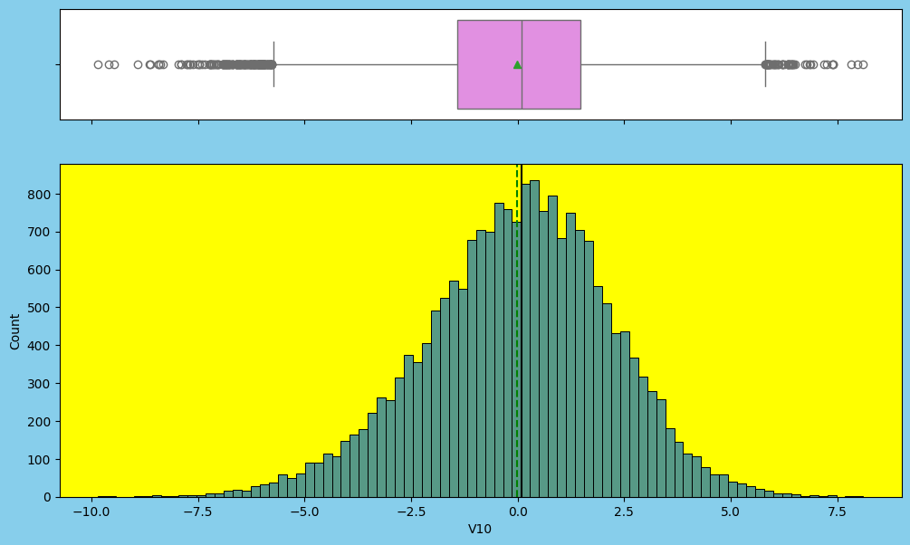

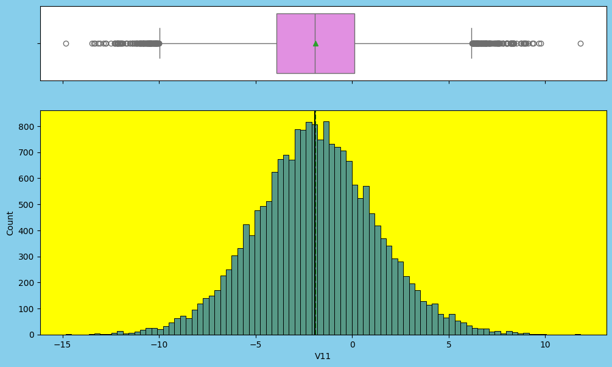

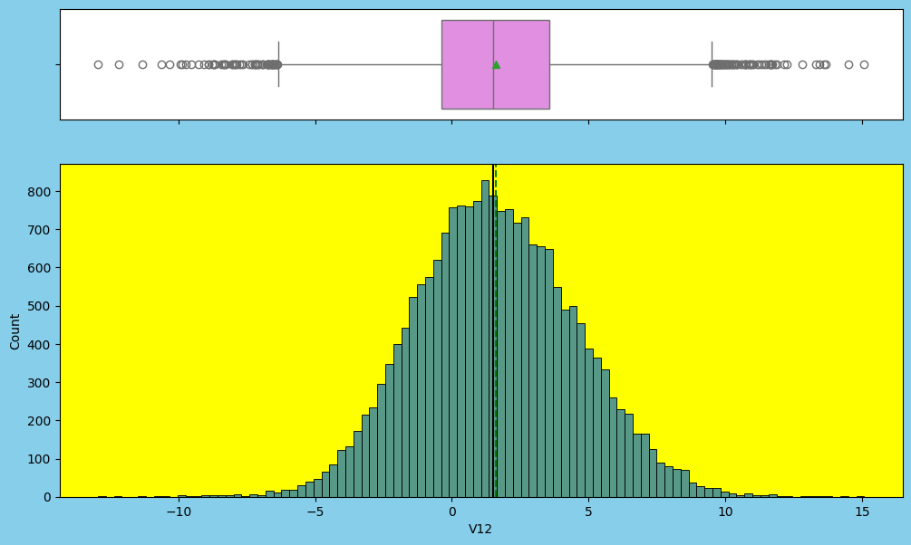

[29 more figures not shown]

```python
# puting df into loop
for feature in df.columns:
    histogram_boxplot(df, feature, figsize=(12, 7), kde=False, bins=None)
    plt.gcf().patch.set_facecolor('skyblue')
    plt.gca().set_facecolor('yellow') ## Please change the dataframe name as you define while reading the data
```

#### Observations:

- all feature are looking similar except target feature. all feature are normally distributed except Target.
- **all feature has outlier.i assume all are real data.**
- In target feature 0(not failure) is quiet highand 1(failure is low).
- target feature is imbalance.

## Checking the corelations

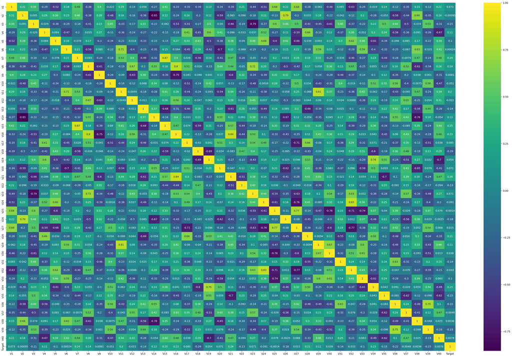

```python
# checking corelations with target feature
plt.figure(figsize=(40,25))
sns.heatmap(df.corr(),annot=True,cmap="viridis")
plt.show()
```

#### Observations:

- target feature is not strongly correleated to any feature.
- v36 and v39 is strongly positive corealeated.
- v19 and v34 is strongly positive coreleation.
- v8 is positive coreleation with v23 and v16.
- v7 and v15 is positive corealeated.so on so forth
- v2 and v14 negative coreleated.

#### Checking outlier

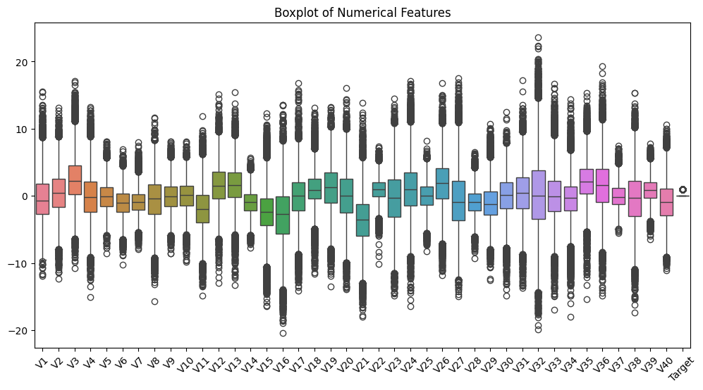

```python
# Plotting box plots for all features
plt.figure(figsize=(12, 6))
sns.boxplot(data=df)
plt.xticks(rotation=45)
plt.title('Boxplot of Numerical Features')
plt.show()
```

#### Observations:

- Every feature has huge outlier.
- Assuming all data Point is real.there is no typo.

```python
# copying data
df1=df.copy()
test=dff.copy()
```

## Data Pre-processing

```python
# train set

# independent feature
X = df1.drop(["Target"], axis=1)
#dependent feature
y = df1["Target"]

# test set
X_test = test.drop(["Target"], axis=1)
y_test = test["Target"]
```

```python
 # splitting the data in 70:30 ratio for train to val data

X_train, X_val, y_train, y_val = train_test_split(X, y, test_size=0.3, random_state=1)

print(X_train.shape, X_val.shape, X_test.shape)
```

```
(14000, 40) (6000, 40) (5000, 40)
```

## Missing value imputation

```python
# imputing the missing value with median value
imputer = SimpleImputer(strategy="median")
```

```python
 # Fit and transform the train data
X_train = pd.DataFrame(imputer.fit_transform(X_train), columns=X_train.columns)
X_val = pd.DataFrame(imputer.fit_transform(X_val), columns=X_val.columns)
X_test = pd.DataFrame(imputer.fit_transform(X_test), columns=X_test.columns)
```

```python
# checking for missing values
print(X_train.isnull().any())
print("-" * 30)
print(X_val.isnull().any())
print("-" * 30)
print(X_test.isnull().any())
```

```
V1     False
V2     False
V3     False
V4     False
V5     False
V6     False
V7     False
V8     False
V9     False
V10    False
V11    False
V12    False
V13    False
V14    False
V15    False
V16    False
V17    False
V18    False
V19    False
V20    False
V21    False
V22    False
V23    False
V24    False
V25    False
V26    False
V27    False
V28    False
V29    False
V30    False
V31    False
V32    False
V33    False
V34    False
V35    False
V36    False
V37    False
V38    False
V39    False
V40    False
```

[output cut: 70 more lines]

```
V27    False
V28    False
V29    False
V30    False
V31    False
V32    False
V33    False
V34    False
V35    False
V36    False
V37    False
V38    False
V39    False
V40    False
dtype: bool
```

**Missing data point has been imputed. now there is no missing value in dataset.**

## Model Building

### Model evaluation criterion

The nature of predictions made by the classification model will translate as follows:

- True positives (TP) are failures correctly predicted by the model.
- False negatives (FN) are real failures in a generator where there is no detection by model.
- False positives (FP) are failure detections in a generator where there is no failure.

**Which metric to optimize?**

- We need to choose the metric which will ensure that the maximum number of generator failures are predicted correctly by the model.
- We would want Recall to be maximized as greater the Recall, the higher the chances of minimizing false negatives.
- We want to minimize false negatives because if a model predicts that a machine will have no failure when there will be a failure, it will increase the maintenance cost.

**Let's define a function to output different metrics (including recall) on the train and test set and a function to show confusion matrix so that we do not have to use the same code repetitively while evaluating models.**

```python
# defining a function to compute different metrics to check performance of a classification model built using sklearn
def model_performance_classification_sklearn(model, predictors, target):
    """
    Function to compute different metrics to check classification model performance

    model: classifier
    predictors: independent variables
    target: dependent variable
    """

    # predicting using the independent variables
    pred = model.predict(predictors)

    acc = accuracy_score(target, pred)  # to compute Accuracy
    recall = recall_score(target, pred)  # to compute Recall
    precision = precision_score(target, pred)  # to compute Precision
    f1 = f1_score(target, pred)  # to compute F1-score

    # creating a dataframe of metrics
    df_perf = pd.DataFrame(
        {
            "Accuracy": acc,
            "Recall": recall,
            "Precision": precision,
            "F1": f1

        },
        index=[0],
    )

    return df_perf
```

```python
# function display confusion matrics
def confusion_matrix_sklearn(model, predictors, target):
    """
    To plot the confusion_matrix with percentages

    model: classifier
    predictors: independent variables
    target: dependent variable
    """
    y_pred = model.predict(predictors)
    cm = confusion_matrix(target, y_pred)
    labels = np.asarray(
        [
            ["{0:0.0f}".format(item) + "\n{0:.2%}".format(item / cm.flatten().sum())]
            for item in cm.flatten()
        ]
    ).reshape(2, 2)

    plt.figure(figsize=(6, 4))
    sns.heatmap(cm, annot=labels, fmt="")
    plt.ylabel("True label")
    plt.xlabel("Predicted label")
```

### Defining scorer to be used for cross-validation and hyperparameter tuning

- We want to reduce false negatives and will try to maximize "Recall".
- To maximize Recall, we can use Recall as a **scorer** in cross-validation and hyperparameter tuning.

```python
# Type of scoring used to compare parameter combinations
scorer = metrics.make_scorer(metrics.recall_score)
```

### Model Building with original data

Sample Decision Tree model building with original data

**Let's start by building different models using StratifiedKFold and cross_val_score and tune the best model using RandomizedSearchCV**

- **stratified Kfold** :- it is particularly important when dealing with imbalanced datasets.
- **Gridsearch cv** -: It gives limited cobination.The combinations it tries are limited to those specified in the grid.
- **RandomizedSearchCV** :- it gives us unlimited combinations search space compare to Gidsearchcv.

```python
models = []  # Empty list to store all the models

# Appending models into the list
models.append(("dtree", DecisionTreeClassifier(random_state=1)))
models.append(("Bagging", BaggingClassifier(random_state=1)))
models.append(("Random forest", RandomForestClassifier(random_state=1)))
models.append(("GBM", GradientBoostingClassifier(random_state=1)))
models.append(("Adaboost", AdaBoostClassifier(random_state=1)))
models.append(("Xgboost", XGBClassifier(random_state=1, eval_metric="logloss")))
models.append(("Logistic regression", LogisticRegression(random_state=1)))


results1 = []  # Empty list to store all model's CV scores
names = []  # Empty list to store name of the models


# loop through all models to get the mean cross validated score
print("\n" "Cross-Validation performance on training dataset:" "\n")

for name, model in models:
    kfold = StratifiedKFold(
        n_splits=5, shuffle=True, random_state=1
    )  # Setting number of splits equal to 5
    cv_result = cross_val_score(
        estimator=model, X=X_train, y=y_train, scoring=scorer, cv=kfold
    )
    results1.append(cv_result)
    names.append(name)
    print("{}: {}".format(name, cv_result.mean()))

print("\n" "Validation Performance:" "\n")

for name, model in models:
    model.fit(X_train, y_train)
    scores = recall_score(y_val, model.predict(X_val))
    print("{}: {}".format(name, scores))
```

```
Cross-Validation performance on training dataset:

dtree: 0.7078246484698097
Bagging: 0.707808105872622
Random forest: 0.7194127377998345
GBM: 0.7220016542597187
Adaboost: 0.6434656741108354
Xgboost: 0.8095368072787427
Logistic regression: 0.4902481389578163

Validation Performance:

dtree: 0.9361702127659575
Bagging: 0.8875379939209727
Random forest: 0.9240121580547113
GBM: 0.7689969604863222
Adaboost: 0.6231003039513677
Xgboost: 0.9574468085106383
Logistic regression: 0.45592705167173253
```

[figure not shown]

```python
 # Plotting boxplots for CV scores of all models defined above
fig = plt.figure(figsize=(10, 7))

fig.suptitle("Algorithm Comparison")
 ax = fig.add_subplot(111)

plt.boxplot(results1)
plt.gcf().patch.set_facecolor('skyblue')
plt.gca().set_facecolor('m')
ax.set_xticklabels(names)

plt.show()
```

**we are getting highest cv_score with xgboost is 80. lets check further.**

### Model Building with Oversampled data

```python
# Synthetic Minority Over Sampling Technique
sm = SMOTE(sampling_strategy=1, k_neighbors=5, random_state=1)
X_train_over, y_train_over = sm.fit_resample(X_train, y_train)
```

```python
print("Before OverSampling, counts of label '1': {}".format(sum(y_train == 1)))
print("Before OverSampling, counts of label '0': {} \n".format(sum(y_train == 0)))

print("After OverSampling, counts of label '1': {}".format(sum(y_train_over == 1)))
print("After OverSampling, counts of label '0': {} \n".format(sum(y_train_over == 0)))

print("After OverSampling, the shape of train_X: {}".format(X_train_over.shape))
print("After OverSampling, the shape of train_y: {} \n".format(y_train_over.shape))
```

```
Before OverSampling, counts of label '1': 781
Before OverSampling, counts of label '0': 13219

After OverSampling, counts of label '1': 13219
After OverSampling, counts of label '0': 13219

After OverSampling, the shape of train_X: (26438, 40)
After OverSampling, the shape of train_y: (26438,)
```

```python
 models_over = []  # Empty list to store all the models

# Appending models into the list
models_over.append(("dtree", DecisionTreeClassifier(random_state=1)))
models_over.append(("Bagging", BaggingClassifier(random_state=1)))
models_over.append(("Random forest", RandomForestClassifier(random_state=1)))
models_over.append(("GBM", GradientBoostingClassifier(random_state=1)))
models_over.append(("Adaboost", AdaBoostClassifier(random_state=1)))
models_over.append(("Xgboost", XGBClassifier(random_state=1, eval_metric="logloss")))
models_over.append(("Logistic regression", LogisticRegression(random_state=1)))

results2 = []  # Empty list to store all model's CV scores
names = []  # Empty list to store name of the models


# loop through all models to get the mean cross validated score
print("\n" "Cross-Validation Performance:" "\n")

for name, model in models_over:
    kfold = StratifiedKFold(
        n_splits=5, shuffle=True, random_state=1
    )  # Setting number of splits equal to 5
    cv_result = cross_val_score(
        estimator=model, X=X_train_over, y=y_train_over, scoring=scorer, cv=kfold
    )
    results2.append(cv_result)
    names.append(name)
    print("{}: {}".format(name, cv_result.mean()))

print("\n" "Validation Performance:" "\n")
for name, model in models_over:
    model.fit(X_train_over, y_train_over)
    scores = recall_score(y_val, model.predict(X_val))
    print("{}: {}".format(name, scores))
```

```
Cross-Validation Performance:

dtree: 0.971329541740435
Bagging: 0.9770028213709836
Random forest: 0.9832058879591166
GBM: 0.9232918799580773
Adaboost: 0.8997650288519384
Xgboost: 0.9915274441149314
Logistic regression: 0.8792647263373178

Validation Performance:

dtree: 0.78419452887538
Bagging: 0.8115501519756839
Random forest: 0.8389057750759878
GBM: 0.8844984802431611
Adaboost: 0.8541033434650456
Xgboost: 0.8723404255319149
Logistic regression: 0.8358662613981763
```

```python
pass
```

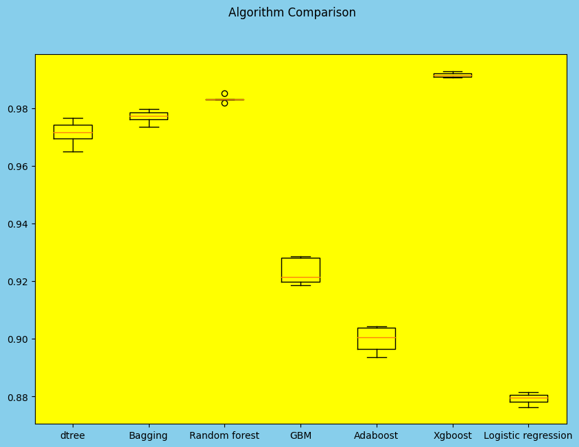

```python
 # Plotting boxplots for CV scores of all models defined above (oversampled)
fig = plt.figure(figsize=(10, 7))

fig.suptitle("Algorithm Comparison")
 ax = fig.add_subplot(111)

plt.boxplot(results2)
plt.gcf().patch.set_facecolor('skyblue')
plt.gca().set_facecolor('yellow')
ax.set_xticklabels(names)

plt.show()
```

**we get good cv-score with train set across all model with over-sampling**

### Model Building with Undersampled data

```python
# Random undersampler for under sampling the data
rus = RandomUnderSampler(random_state=1, sampling_strategy=1)
X_train_un, y_train_un = rus.fit_resample(X_train, y_train)
```

```python
print("Before UnderSampling, counts of label '1': {}".format(sum(y_train == 1)))
print("Before UnderSampling, counts of label '0': {} \n".format(sum(y_train == 0)))
print("After UnderSampling, counts of label '1': {}".format(sum(y_train_un == 1)))
print("After UnderSampling, counts of label '0': {} \n".format(sum(y_train_un == 0)))
print("After UnderSampling, the shape of train_X: {}".format(X_train_un.shape))
print("After UnderSampling, the shape of train_y: {} \n".format(y_train_un.shape))
```

```
Before UnderSampling, counts of label '1': 781
Before UnderSampling, counts of label '0': 13219

After UnderSampling, counts of label '1': 781
After UnderSampling, counts of label '0': 781

After UnderSampling, the shape of train_X: (1562, 40)
After UnderSampling, the shape of train_y: (1562,)
```

```python
 models_under = []  # Empty list to store all the models

# Appending models into the list
models_under.append(("dtree", DecisionTreeClassifier(random_state=1)))
models_under.append(("Bagging", BaggingClassifier(random_state=1)))
models_under.append(("Random forest", RandomForestClassifier(random_state=1)))
models_under.append(("GBM", GradientBoostingClassifier(random_state=1)))
models_under.append(("Adaboost", AdaBoostClassifier(random_state=1)))
models_under.append(("Xgboost", XGBClassifier(random_state=1, eval_metric="logloss")))
models_under.append(("Logistic regression", LogisticRegression(random_state=1)))


results3 = []  # Empty list to store all model's CV scores
names = []  # Empty list to store name of the models


# loop through all models to get the mean cross validated score
print("\n" "Cross-Validation Performance:" "\n")

for name, model in models_under:
    kfold = StratifiedKFold(
        n_splits=5, shuffle=True, random_state=1
    )  # Setting number of splits equal to 5
    cv_result = cross_val_score(
        estimator=model, X=X_train_un, y=y_train_un, scoring=scorer, cv=kfold
    )
    results3.append(cv_result)
    names.append(name)
    print("{}: {}".format(name, cv_result.mean()))

print("\n" "Validation Performance:" "\n")

for name, model in models_under:
    model.fit(X_train_un, y_train_un)
    scores = recall_score(y_val, model.predict(X_val))
    print("{}: {}".format(name, scores))
```

```
Cross-Validation Performance:

dtree: 0.8488731014208721
Bagging: 0.8565817409766454
Random forest: 0.8872856442920136
GBM: 0.8834313245141271
Adaboost: 0.8642087212150906
Xgboost: 0.8936714029070716
Logistic regression: 0.8476400457292177

Validation Performance:

dtree: 0.8389057750759878
Bagging: 0.8480243161094225
Random forest: 0.8814589665653495
GBM: 0.8905775075987842
Adaboost: 0.8541033434650456
Xgboost: 0.8966565349544073
Logistic regression: 0.8358662613981763
```

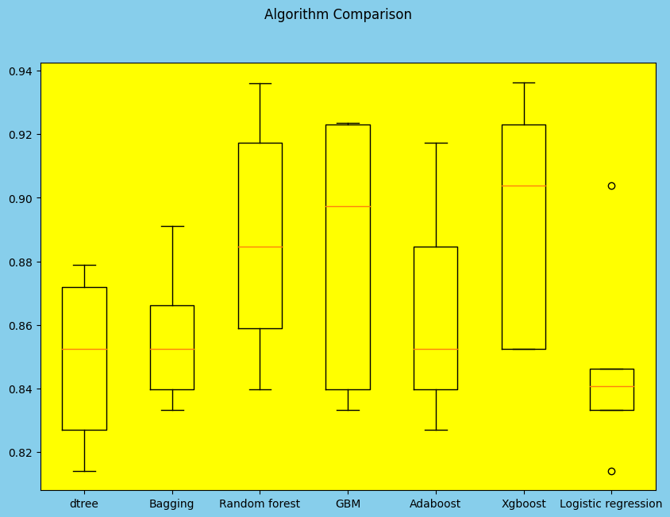

```python
 # Plotting boxplots for CV scores of all models defined above (undersampled)
fig = plt.figure(figsize=(10, 7))

fig.suptitle("Algorithm Comparison")
 ax = fig.add_subplot(111)

plt.boxplot(results3)
plt.gcf().patch.set_facecolor('skyblue')
plt.gca().set_facecolor('yellow')
ax.set_xticklabels(names)

plt.show()
```

**xgboost and random forest is givig highest cv score**

**further we are going to tuning some models**

## HyperparameterTuning

**We will tune some models with RandomizedSearchCV. We will also compare the performance of the model.**

## XG BOOSTING

#### Tuning XG boosting ⚛ original

```python
%%time

# defining model
xgb_org = XGBClassifier(random_state=1,eval_metric='logloss')

# Parameter grid to pass in RandomizedSearchCV
param_grid={'n_estimators':np.arange(50,150,50),
            'scale_pos_weight':[2,5,10],
            'learning_rate':[0.01,0.1,0.2,0.05],
            'gamma':[0,1,3,5],
            'subsample':[0.8,0.9,1],
            'max_depth':np.arange(1,5,1),
            'reg_lambda':[5,10]}

# Type of scoring used to compare parameter combinations
scorer = metrics.make_scorer(metrics.recall_score)

#Calling RandomizedSearchCV
xgb_tuned = RandomizedSearchCV(estimator=xgb_org, param_distributions=param_grid, n_iter=50, scoring=scorer, cv=5, random_state=1, n_jobs = -1)

#Fitting parameters in RandomizedSearchCV
xgb_tuned.fit(X_train,y_train)

print("Best parameters are {} with CV score={}:" .format(xgb_tuned.best_params_,xgb_tuned.best_score_))
```

```
Best parameters are {'subsample': 0.9, 'scale_pos_weight': 10, 'reg_lambda': 5, 'n_estimators': 50, 'max_depth': 3, 'learning_rate': 0.2, 'gamma': 0} with CV score=0.863024661113833:
CPU times: user 2.26 s, sys: 274 ms, total: 2.53 s
Wall time: 1min 24s
```

#### Tuning XG boosting ⚛ oversampled

```python
%%time

# defining model
xgb_over = XGBClassifier(random_state=1,eval_metric='logloss')

# Parameter grid to pass in RandomizedSearchCV
param_grid={'n_estimators':np.arange(50,150,50),
            'scale_pos_weight':[2,5,10],
            'learning_rate':[0.01,0.1,0.2,0.05],
            'gamma':[0,1,3,5],
            'subsample':[0.8,0.9,1],
            'max_depth':np.arange(1,5,1),
            'reg_lambda':[5,10]}

# Type of scoring used to compare parameter combinations
scorer = metrics.make_scorer(metrics.recall_score)

#Calling RandomizedSearchCV
xgb_tuned = RandomizedSearchCV(estimator=xgb_over, param_distributions=param_grid, n_iter=50, scoring=scorer, cv=5, random_state=1, n_jobs = -1)

#Fitting parameters in RandomizedSearchCV
xgb_tuned.fit(X_train_over,y_train_over)

print("Best parameters are {} with CV score={}:" .format(xgb_tuned.best_params_,xgb_tuned.best_score_))
```

```
Best parameters are {'subsample': 0.9, 'scale_pos_weight': 5, 'reg_lambda': 10, 'n_estimators': 50, 'max_depth': 3, 'learning_rate': 0.01, 'gamma': 3} with CV score=1.0:
CPU times: user 2.8 s, sys: 293 ms, total: 3.1 s
Wall time: 2min 1s
```

#### Tuning XG boosting ⚛ undersampled

```python
%%time

# defining model
xgb_under = XGBClassifier(random_state=1,eval_metric='logloss')

# Parameter grid to pass in RandomizedSearchCV
param_grid={'n_estimators':np.arange(50,150,50),
            'scale_pos_weight':[2,5,10],
            'learning_rate':[0.01,0.1,0.2,0.05],
            'gamma':[0,1,3,5],
            'subsample':[0.8,0.9,1],
            'max_depth':np.arange(1,5,1),
            'reg_lambda':[5,10]}

# Type of scoring used to compare parameter combinations
scorer = metrics.make_scorer(metrics.recall_score)

#Calling RandomizedSearchCV
xgb_tuned = RandomizedSearchCV(estimator=xgb_under, param_distributions=param_grid, n_iter=50, scoring=scorer, cv=5, random_state=1, n_jobs = -1)

#Fitting parameters in RandomizedSearchCV
xgb_tuned.fit(X_train_un,y_train_un)

print("Best parameters are {} with CV score={}:" .format(xgb_tuned.best_params_,xgb_tuned.best_score_))
```

```
Best parameters are {'subsample': 0.9, 'scale_pos_weight': 5, 'reg_lambda': 10, 'n_estimators': 50, 'max_depth': 3, 'learning_rate': 0.01, 'gamma': 3} with CV score=1.0:
CPU times: user 1.41 s, sys: 141 ms, total: 1.55 s
Wall time: 41 s
```

## Gradient boosting

#### Tuning Gradient boosting ⚛ original

```python
%%time
# defining model
gb = GradientBoostingClassifier(random_state=1)
 #Parameter grid to pass in RandomSearchCV
param_grid={
    "n_estimators": np.arange(100,150,25),
    "learning_rate": [0.2, 0.05, 1],
    "subsample":[0.5,0.7],
    "max_features":[0.5,0.7]}


#Calling RandomizedSearchCV
randomized_cv = RandomizedSearchCV(estimator=gb, param_distributions=param_grid, scoring=scorer, n_iter=50, n_jobs = -1, cv=5, random_state=1)

#Fitting parameters in RandomizedSearchCV
randomized_cv.fit(X_train, y_train)

print("Best parameters are {} with CV score={}:" .format(randomized_cv.best_params_,randomized_cv.best_score_))
```

```
Best parameters are {'subsample': 0.7, 'n_estimators': 125, 'max_features': 0.7, 'learning_rate': 0.2} with CV score=0.7605830475257227:
```

#### Tuning Gradient boosting ⚛ oversampled

```python
%%time
# defining model
gb_over = GradientBoostingClassifier(random_state=1)
 #Parameter grid to pass in RandomSearchCV
param_grid={
    "n_estimators": np.arange(100,150,25),
    "learning_rate": [0.2, 0.05, 1],
    "subsample":[0.5,0.7],
    "max_features":[0.5,0.7]}
#Calling RandomizedSearchCV
randomized_cv = RandomizedSearchCV(estimator=gb_over, param_distributions=param_grid, scoring=scorer, n_iter=50, n_jobs = -1, cv=5, random_state=1)

#Fitting parameters in RandomizedSearchCV
randomized_cv.fit(X_train_over, y_train_over)

print("Best parameters are {} with CV score={}:" .format(randomized_cv.best_params_,randomized_cv.best_score_))
```

```
Best parameters are {'subsample': 0.7, 'n_estimators': 125, 'max_features': 0.5, 'learning_rate': 1} with CV score=0.9704971829220336:
```

#### Tuning Gradient boosting ⚛ undersampled

```python
%%time
# defining model
gb_under = GradientBoostingClassifier(random_state=1)
 #Parameter grid to pass in RandomSearchCV
param_grid={
    "n_estimators": np.arange(100,150,25),
    "learning_rate": [0.2, 0.05, 1],
    "subsample":[0.5,0.7],
    "max_features":[0.5,0.7]}

#Calling RandomizedSearchCV
randomized_cv = RandomizedSearchCV(estimator=gb_under, param_distributions=param_grid, scoring=scorer, n_iter=50, n_jobs = -1, cv=5, random_state=1)

#Fitting parameters in RandomizedSearchCV
randomized_cv.fit(X_train_un, y_train_un)

print("Best parameters are {} with CV score={}:" .format(randomized_cv.best_params_,randomized_cv.best_score_))
```

```
Best parameters are {'subsample': 0.5, 'n_estimators': 100, 'max_features': 0.5, 'learning_rate': 0.2} with CV score=0.8949779519843215:
```